# indivdual1

```r
library(readxl)
library(readr)
library(tidyr)
library(dplyr)
library(tidyverse)
```

```r
defense <- read_excel('../ds202_lab4/cyclonesFootball2019.xlsx', sheet='Defensive')
biography <- read_excel('../ds202_lab4/cyclonesFootball2019.xlsx', sheet='Biography')
offensive <- read_excel('../ds202_lab4/cyclonesFootball2019.xlsx', sheet='Offensive')
str(defense)
```

```
## tibble [502 x 11] (S3: tbl_df/tbl/data.frame)
##  $ Name             : chr [1:502] "White, Lawrence" "White, Lawrence" "White, Lawrence" "White, Lawrence" ...
##  $ Opponent_Opponent: chr [1:502] "UNI" "Iowa" "ULM" "Baylor" ...
##  $ Tackles_Solo     : chr [1:502] "4" "4" "3" "4" ...
##  $ Tackles_ASST     : chr [1:502] "4" "7" "5" "2" ...
##  $ Tackles_TFL      : chr [1:502] "0" "0" "0" "0" ...
##  $ Tackles_Sack     : chr [1:502] "0" "0" "0" "0" ...
##  $ Turnover_FF      : chr [1:502] "0" "0" "0" "0" ...
##  $ Turnover_FR      : chr [1:502] "0" "0" "0" "0" ...
##  $ Turnover_INT     : chr [1:502] "0" "0" "1" "0" ...
##  $ Pass_QBH         : chr [1:502] "1" "0" "0" "0" ...
##  $ Pass_PB          : chr [1:502] "1" "2" "0" "0" ...
```

```r
str(biography)
```

```
## tibble [105 x 7] (S3: tbl_df/tbl/data.frame)
##  $ Name      : chr [1:105] "Akers, Landen" "Allen, Chase" "Anderson, Ezeriah" "Assalley, Connor" ...
##  $ Position  : chr [1:105] "Wide Receiver" "Tight End" "Wide Receiver" "Placekicker" ...
##  $ Height    : chr [1:105] "6-0" "6-7" "6-5" "6-0" ...
##  $ Weight    : chr [1:105] "188" "245" "204" "195" ...
##  $ Class     : chr [1:105] "Redshirt Senior" "Redshirt Senior" "Redshirt Freshman" "Redshirt Senior" ...
##  $ Hometown  : chr [1:105] "Cedar Rapids, Iowa" "Nixa, Mo." "Seffner, Fla." "Naperville, Ill." ...
##  $ Highschool: chr [1:105] "Washington" "Nixa" "Armwood" "Central" ...
```

```r
str(offensive)
```

```
## tibble [195 x 12] (S3: tbl_df/tbl/data.frame)
##  $ Name             : chr [1:195] "Akers, Landen" "Akers, Landen" "Akers, Landen" "Akers, Landen" ...
##  $ Opponent_Opponent: chr [1:195] "UNI" "Iowa" "ULM" "Baylor" ...
##  $ Rushing_ATT      : chr [1:195] "0" "0" "1" "0" ...
##  $ Rushing_YDS      : chr [1:195] "0" "0" "8" "0" ...
##  $ Rushing_TD       : chr [1:195] "0" "0" "0" "0" ...
##  $ Receiving_REC    : chr [1:195] "1" "0" "0" "0" ...
##  $ Receiving_YDS    : chr [1:195] "21" "0" "0" "0" ...
##  $ Receiving_TD     : chr [1:195] "0" "0" "0" "0" ...
##  $ Passing_CMP-ATT  : chr [1:195] NA NA NA NA ...
##  $ Passing_YDS      : chr [1:195] NA NA NA NA ...
##  $ Passing_TD       : chr [1:195] NA NA NA NA ...
##  $ Passing_INT      : chr [1:195] NA NA NA NA ...
```

```r
defClean <- defense %>% mutate(name = factor(Name), opponent = factor(Opponent_Opponent)) %>%
            mutate(across(Tackles_Solo:Pass_PB, as.integer))%>% select(-Name, -Opponent_Opponent)

offClean <- offensive %>% mutate(name = factor(Name), opponent = factor(Opponent_Opponent)) %>%
            mutate(across(Rushing_ATT:Passing_INT, as.integer)) %>% select(-Name, -Opponent_Opponent)
```

```r
bioClean <- biography %>% separate(Height, c('Feet','Inches') , sep='-') %>% mutate(total_inches = as.integer(Feet)*12 + as.integer(Inches)) %>% select(-Feet,-Inches)

str(bioClean)
```

```
## tibble [105 x 7] (S3: tbl_df/tbl/data.frame)
##  $ Name        : chr [1:105] "Akers, Landen" "Allen, Chase" "Anderson, Ezeriah" "Assalley, Connor" ...
##  $ Position    : chr [1:105] "Wide Receiver" "Tight End" "Wide Receiver" "Placekicker" ...
##  $ Weight      : chr [1:105] "188" "245" "204" "195" ...
##  $ Class       : chr [1:105] "Redshirt Senior" "Redshirt Senior" "Redshirt Freshman" "Redshirt Senior" ...
##  $ Hometown    : chr [1:105] "Cedar Rapids, Iowa" "Nixa, Mo." "Seffner, Fla." "Naperville, Ill." ...
##  $ Highschool  : chr [1:105] "Washington" "Nixa" "Armwood" "Central" ...
##  $ total_inches: num [1:105] 72 79 77 72 72 75 74 74 72 78 ...
```

```r
str(defClean)
```

```
## tibble [502 x 11] (S3: tbl_df/tbl/data.frame)
##  $ Tackles_Solo: int [1:502] 4 4 3 4 3 1 7 3 6 5 ...
##  $ Tackles_ASST: int [1:502] 4 7 5 2 2 1 1 2 1 5 ...
##  $ Tackles_TFL : int [1:502] 0 0 0 0 1 0 0 0 1 1 ...
##  $ Tackles_Sack: int [1:502] 0 0 0 0 0 0 0 0 0 1 ...
##  $ Turnover_FF : int [1:502] 0 0 0 0 0 0 0 0 0 0 ...
##  $ Turnover_FR : int [1:502] 0 0 0 0 0 0 0 0 0 0 ...
##  $ Turnover_INT: int [1:502] 0 0 1 0 0 0 0 0 1 0 ...
##  $ Pass_QBH    : int [1:502] 1 0 0 0 0 0 0 0 1 0 ...
##  $ Pass_PB     : int [1:502] 1 2 0 0 0 1 0 0 0 0 ...
##  $ name        : Factor w/ 43 levels "Akers, Landen",..: 40 40 40 40 40 40 40 40 40 40 ...
##  $ opponent    : Factor w/ 13 levels "Baylor","Iowa",..: 12 2 11 1 8 13 10 7 6 9 ...
```

```r
str(offClean)
```

```
## tibble [195 x 12] (S3: tbl_df/tbl/data.frame)
##  $ Rushing_ATT    : int [1:195] 0 0 1 0 0 0 0 0 0 0 ...
##  $ Rushing_YDS    : int [1:195] 0 0 8 0 0 0 0 0 0 0 ...
##  $ Rushing_TD     : int [1:195] 0 0 0 0 0 0 0 0 0 0 ...
##  $ Receiving_REC  : int [1:195] 1 0 0 0 1 0 0 4 0 1 ...
##  $ Receiving_YDS  : int [1:195] 21 0 0 0 32 0 0 39 0 7 ...
##  $ Receiving_TD   : int [1:195] 0 0 0 0 0 0 0 0 0 0 ...
##  $ Passing_CMP-ATT: int [1:195] NA NA NA NA NA NA NA NA NA NA ...
##  $ Passing_YDS    : int [1:195] NA NA NA NA NA NA NA NA NA NA ...
##  $ Passing_TD     : int [1:195] NA NA NA NA NA NA NA NA NA NA ...
##  $ Passing_INT    : int [1:195] NA NA NA NA NA NA NA NA NA NA ...
##  $ name           : Factor w/ 17 levels "Akers, Landen",..: 1 1 1 1 1 1 1 1 1 1 ...
##  $ opponent       : Factor w/ 13 levels "Baylor","Iowa",..: 12 2 11 1 8 13 10 7 6 9 ...
```

```r
defClean <- defClean %>%
  pivot_longer(Tackles_Solo:Pass_PB, names_to = "Stats")
str(defClean)
```

```
## tibble [4,518 x 4] (S3: tbl_df/tbl/data.frame)
##  $ name    : Factor w/ 43 levels "Akers, Landen",..: 40 40 40 40 40 40 40 40 40 40 ...
##  $ opponent: Factor w/ 13 levels "Baylor","Iowa",..: 12 12 12 12 12 12 12 12 12 2 ...
##  $ Stats   : chr [1:4518] "Tackles_Solo" "Tackles_ASST" "Tackles_TFL" "Tackles_Sack" ...
##  $ value   : int [1:4518] 4 4 0 0 0 0 0 1 1 4 ...
```

```r
aggregateDef <- aggregate(defClean$value, by= list(defClean$Stats), FUN= sum)
aggregateDef
```

```
##        Group.1   x
## 1      Pass_PB  48
## 2     Pass_QBH  30
## 3 Tackles_ASST 336
## 4 Tackles_Sack  22
## 5 Tackles_Solo 483
## 6  Tackles_TFL  66
## 7  Turnover_FF  10
## 8  Turnover_FR   7
## 9 Turnover_INT   6
```

P2 2. Well the solo and group tackles are plentiful. What defensive skill is low is in the turnover column. There are very few FF, FR, and INT compared to the tackles and passing defensive skills. In the turnover category there are 10 or less in each category whereas in every other defensive category there are more than 10 by far.

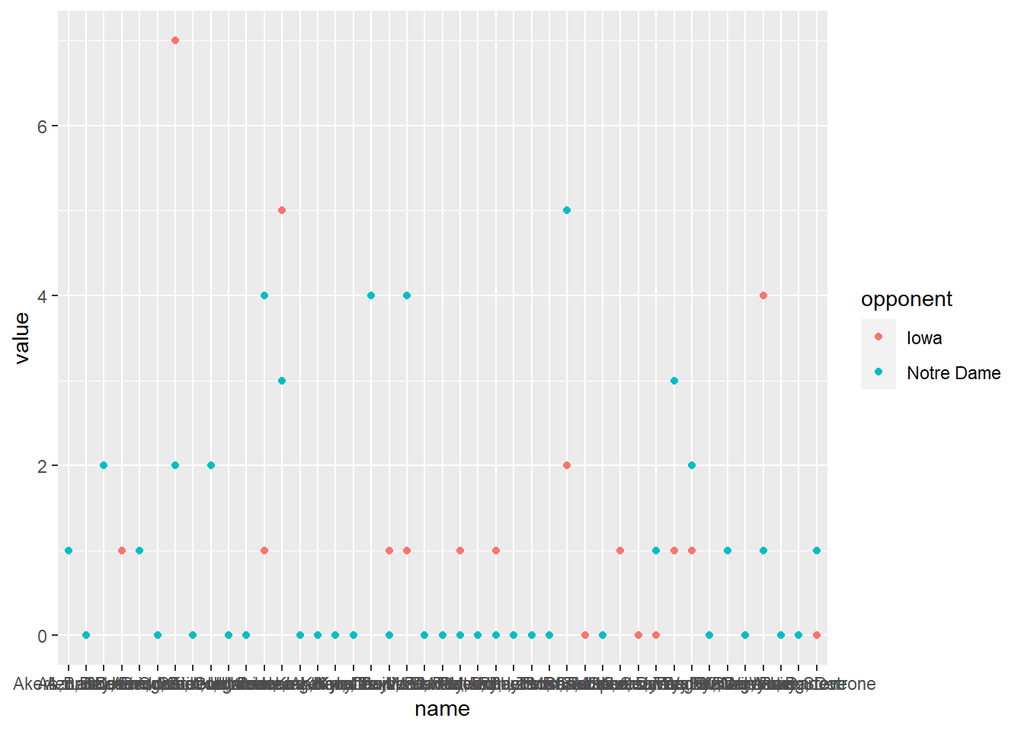

```r
notreDame <- defClean %>% filter( opponent =="Notre Dame" & Stats == 'Tackles_Solo')
iowa <- defClean %>% filter( opponent =="Iowa"&Stats == 'Tackles_Solo')
both <- rbind(iowa,notreDame)
ggplot(both , aes(x=name, y=value , colour = opponent)) +geom_point()
```

P2 3. ISu had better solo tackling in the notre Dame game there were more notre dame points on the scatter plot that were higher than iowa. This would indicate more solo tackles at the notre dame game.

```r
bioClean <- biography %>% separate(Hometown, c('City','State') , sep=', ')
head(bioClean , n=5)
```

```
## # A tibble: 5 x 8
##   Name         Position     Height Weight Class       City      State Highschool
##   <chr>        <chr>        <chr>  <chr>  <chr>       <chr>     <chr> <chr>
## 1 Akers, Land~ Wide Receiv~ 6-0    188    Redshirt S~ Cedar Ra~ Iowa  Washington
## 2 Allen, Chase Tight End    6-7    245    Redshirt S~ Nixa      Mo.   Nixa
## 3 Anderson, E~ Wide Receiv~ 6-5    204    Redshirt F~ Seffner   Fla.  Armwood
## 4 Assalley, C~ Placekicker  6-0    195    Redshirt S~ Napervil~ Ill.  Central
## 5 Azunna, Arn~ Defensive B~ 6-0    190    Redshirt S~ Grand Pr~ Texas Lake Ridge
```

```r
bioCount <- bioClean %>% count(State)
bioCount
```

```
## # A tibble: 19 x 2
##    State         n
##    <chr>     <int>
##  1 Ariz.         4
##  2 Ark.          1
##  3 Australia     1
##  4 Calif.        3
##  5 Fla.         10
##  6 Ga.           4
##  7 Ill.          5
##  8 Iowa         35
##  9 Kan.          3
## 10 Mich.         4
## 11 Minn.         4
## 12 Miss.         1
## 13 Mo.           6
## 14 Ohio          7
## 15 Okla.         2
## 16 Pa.           1
## 17 S.D.          2
## 18 Texas         6
## 19 Wis.          6
```

##Part 3

## 1.

```r
bioClean <- bioClean %>% rename(name = 'Name')
offGroup <- offClean %>% select(name) %>% group_by(name)
offGroup <-unique(offGroup)
joinOff <- inner_join(bioClean, offGroup, by = "name")
offState <- joinOff %>% count(State)


deffGroup <-defClean %>% select(name) %>% group_by(name)
deffGroup <-unique(deffGroup)
joinDef <- inner_join(bioClean, deffGroup, by = "name")
joinDef <- joinDef %>% count(State)

offState
```

```
## # A tibble: 11 x 2
##    State     n
##    <chr> <int>
##  1 Ariz.     1
##  2 Ark.      1
##  3 Fla.      2
##  4 Ga.       1
##  5 Ill.      1
##  6 Iowa      1
##  7 Kan.      1
##  8 Mo.       1
##  9 Ohio      1
## 10 Okla.     2
## 11 Texas     1
```

```r
joinDef
```

```
## # A tibble: 12 x 2
##    State      n
##    <chr>  <int>
##  1 Ark.       1
##  2 Calif.     2
##  3 Fla.       4
##  4 Ga.        3
##  5 Iowa       7
##  6 Kan.       1
##  7 Mich.      1
##  8 Mo.        2
##  9 Ohio       3
## 10 Okla.      2
## 11 Texas      2
## 12 Wis.       2
```

2. If brock purdy is doing well then there is alot of passing yards, which would open up the field and let in alot of rushing yards

```r
brock <- offClean %>%  filter(name == "Purdy, Brock") %>% select(opponent, Passing_YDS, Passing_TD, Passing_INT)

rushing <- offClean %>% group_by(opponent) %>% summarize(rush_yds = sum(Rushing_YDS,na.rm = TRUE), rush_attp = sum(Rushing_ATT,na.rm = TRUE), rtd = sum(Rushing_TD,na.rm = TRUE))
combineStats <- inner_join(rushing, brock, by="opponent")
combineStats
```

```
## # A tibble: 13 x 7
##    opponent       rush_yds rush_attp   rtd Passing_YDS Passing_TD Passing_INT
##    <fct>             <int>     <int> <int>       <int>      <int>       <int>
##  1 Baylor               63        28     1         342          2           1
##  2 Iowa                 91        19     0         276          1           0
##  3 Kansas              118        34     2         372          4           1
##  4 Kansas State         56        23     1         185          1           0
##  5 Notre Dame           45        27     0         222          0           0
##  6 Oklahoma            197        37     1         282          5           0
##  7 Oklahoma State       86        25     2         382          1           3
##  8 TCU                 193        34     4         247          2           0
##  9 Texas               114        29     0         354          2           1
## 10 Texas Tech          186        23     2         378          3           1
## 11 ULM                 274        36     4         435          3           1
## 12 UNI                 185        45     1         278          2           0
## 13 West Virginia       146        40     4         229          1           1
```

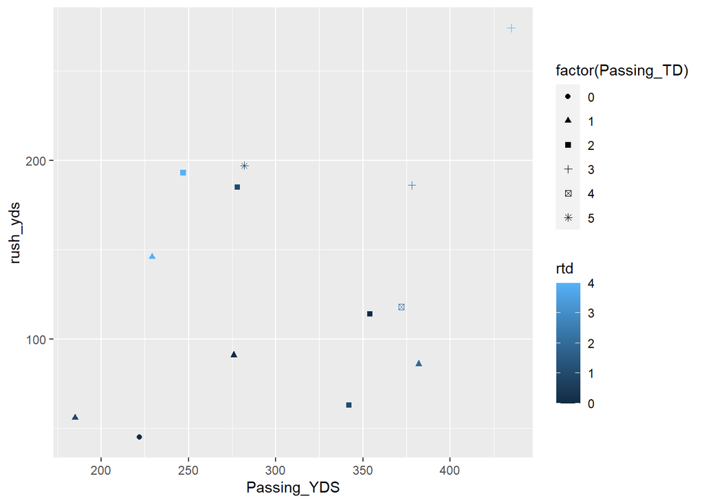

```r
ggplot(combineStats, aes(Passing_YDS, rush_yds, shape = factor(Passing_TD), colour = rtd)) + geom_point()
```

##Clean some data

```r
defense2 <- read_excel('../ds202_lab4/cyclonesFootball2018.xlsx', sheet='Defensive')
biography2 <- read_excel('../ds202_lab4/cyclonesFootball2018.xlsx', sheet='Biography')
offensive2 <- read_excel('../ds202_lab4/cyclonesFootball2018.xlsx', sheet='Offensive')

defClean2 <- defense2 %>% mutate(name = factor(Name), opponent = factor(Opponent_Opponent)) %>%
            mutate(across(Tackles_Solo:Pass_PB, as.integer))%>% select(-Name, -Opponent_Opponent)

offClean2 <- offensive2 %>% mutate(name = factor(Name), opponent = factor(Opponent_Opponent)) %>%
            mutate(across(Rushing_ATT:Passing_INT, as.integer)) %>% select(-Name, -Opponent_Opponent)
bioClean2 <- biography2 %>% separate(Height, c('Feet','Inches') , sep='-') %>% mutate(total_inches = as.integer(Feet)*12 + as.integer(Inches)) %>% select

 defClean2<-defClean2 %>%
  pivot_longer(Tackles_Solo:Pass_PB, names_to = "Stats")
str(defClean2)
```

```
## tibble [4,014 x 4] (S3: tbl_df/tbl/data.frame)
##  $ name    : Factor w/ 42 levels "Akers, Landen",..: 7 7 7 7 7 7 7 7 7 7 ...
##  $ opponent: Factor w/ 13 levels "Akron","Baylor",..: 4 4 4 4 4 4 4 4 4 7 ...
##  $ Stats   : chr [1:4014] "Tackles_Solo" "Tackles_ASST" "Tackles_TFL" "Tackles_Sack" ...
##  $ value   : int [1:4014] 3 3 0 0 0 0 0 0 0 6 ...
```

##Compare some data The data will only have shared opponents to see how much they really improved against common data points

```r
twoDef <- inner_join(defClean2, defClean , by= c("name" , "Stats", "opponent"))
twoDef <- twoDef %>% group_by(Stats) %>% rename(twentyEighteen = value.x , twentyNineteen = value.y) %>% filter(Stats== 'Tackles_Solo')
twoDef <- twoDef %>% pivot_longer(twentyEighteen:twentyNineteen , names_to = "year")
twoDef
```

```
## # A tibble: 382 x 5
## # Groups:   Stats [1]
##    name           opponent       Stats        year           value
##    <fct>          <fct>          <chr>        <chr>          <int>
##  1 Eisworth, Greg Iowa           Tackles_Solo twentyEighteen     3
##  2 Eisworth, Greg Iowa           Tackles_Solo twentyNineteen     7
##  3 Eisworth, Greg Oklahoma       Tackles_Solo twentyEighteen     6
##  4 Eisworth, Greg Oklahoma       Tackles_Solo twentyNineteen     2
##  5 Eisworth, Greg TCU            Tackles_Solo twentyEighteen     6
##  6 Eisworth, Greg TCU            Tackles_Solo twentyNineteen     3
##  7 Eisworth, Greg Oklahoma State Tackles_Solo twentyEighteen     3
##  8 Eisworth, Greg Oklahoma State Tackles_Solo twentyNineteen     0
##  9 Eisworth, Greg Texas Tech     Tackles_Solo twentyEighteen     3
## 10 Eisworth, Greg Texas Tech     Tackles_Solo twentyNineteen     3
## # ... with 372 more rows
```

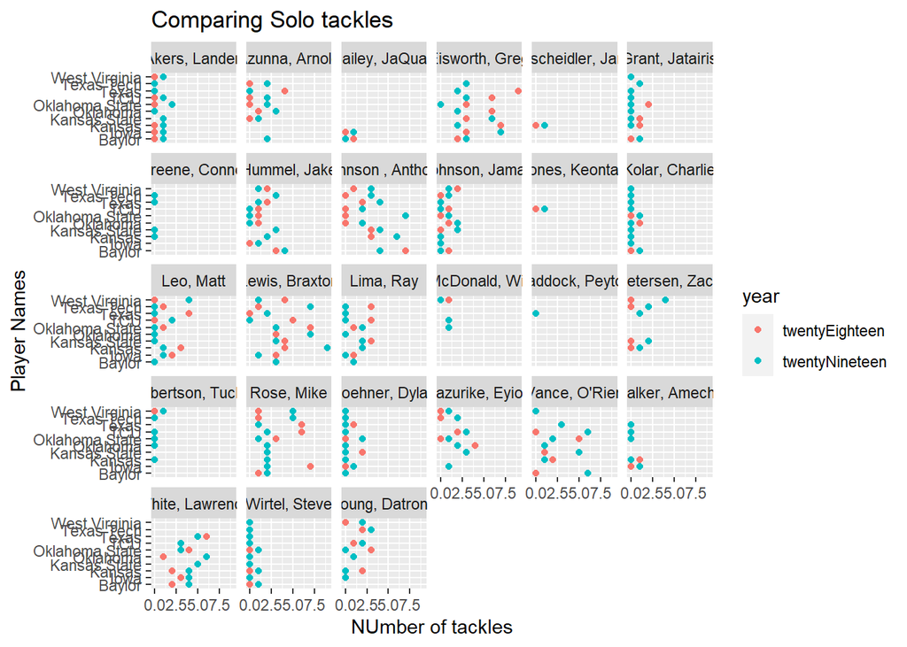

```r
ggplot(twoDef, aes(value, twoDef$opponent, colour = year)) + geom_point() + facet_wrap(twoDef$name) +labs(title = "Comparing Solo tackles",
         x = "NUmber of tackles",
         y = "Player Names")
```

```r
head(twoDef, n =50)
```

```
## # A tibble: 50 x 5
## # Groups:   Stats [1]
##    name           opponent       Stats        year           value
##    <fct>          <fct>          <chr>        <chr>          <int>
##  1 Eisworth, Greg Iowa           Tackles_Solo twentyEighteen     3
##  2 Eisworth, Greg Iowa           Tackles_Solo twentyNineteen     7
##  3 Eisworth, Greg Oklahoma       Tackles_Solo twentyEighteen     6
##  4 Eisworth, Greg Oklahoma       Tackles_Solo twentyNineteen     2
##  5 Eisworth, Greg TCU            Tackles_Solo twentyEighteen     6
##  6 Eisworth, Greg TCU            Tackles_Solo twentyNineteen     3
##  7 Eisworth, Greg Oklahoma State Tackles_Solo twentyEighteen     3
##  8 Eisworth, Greg Oklahoma State Tackles_Solo twentyNineteen     0
##  9 Eisworth, Greg Texas Tech     Tackles_Solo twentyEighteen     3
## 10 Eisworth, Greg Texas Tech     Tackles_Solo twentyNineteen     3
## # ... with 40 more rows
```